# Risk Factor Analysis

## Outcome Variable

**Outcome Variable:** dead0plus

## Predictor Variables

**Intervention Variable:** ever_wasted024

**Adjustment Set:**

- sex
- arm
- brthmon
- vagbrth
- hhwealth_quart
- W_mage
- W_mhtcm
- W_mwtkg
- W_mbmi
- W_meducyrs
- W_feducyrs
- W_nrooms
- W_parity
- impsan
- safeh20
- delta_vagbrth
- delta_hhwealth_quart
- delta_W_mage
- delta_W_mhtcm
- delta_W_mwtkg
- delta_W_mbmi
- delta_W_meducyrs
- delta_W_feducyrs
- delta_W_nrooms
- delta_W_parity
- delta_impsan
- delta_safeh20

## Stratifying Variables

The analysis was stratified on these variable(s):

- studyid
- country

## Data Summary

| studyid | country | ever_wasted024 | dead0plus | n_cell | n |
| --- | --- | --- | --- | --- | --- |
| Burkina Faso Zn | BURKINA FASO | 0 | 0 | 5730 | 7166 |
| Burkina Faso Zn | BURKINA FASO | 0 | 1 | 30 | 7166 |
| Burkina Faso Zn | BURKINA FASO | 1 | 0 | 1388 | 7166 |
| Burkina Faso Zn | BURKINA FASO | 1 | 1 | 18 | 7166 |
| EE | PAKISTAN | 0 | 0 | 153 | 380 |
| EE | PAKISTAN | 0 | 1 | 1 | 380 |
| EE | PAKISTAN | 1 | 0 | 223 | 380 |
| EE | PAKISTAN | 1 | 1 | 3 | 380 |
| GMS-Nepal | NEPAL | 0 | 0 | 276 | 686 |
| GMS-Nepal | NEPAL | 0 | 1 | 5 | 686 |
| GMS-Nepal | NEPAL | 1 | 0 | 403 | 686 |
| GMS-Nepal | NEPAL | 1 | 1 | 2 | 686 |
| iLiNS-DOSE | MALAWI | 0 | 0 | 1660 | 1931 |
| iLiNS-DOSE | MALAWI | 0 | 1 | 113 | 1931 |
| iLiNS-DOSE | MALAWI | 1 | 0 | 143 | 1931 |
| iLiNS-DOSE | MALAWI | 1 | 1 | 15 | 1931 |
| iLiNS-DYAD-M | MALAWI | 0 | 0 | 1058 | 1201 |
| iLiNS-DYAD-M | MALAWI | 0 | 1 | 33 | 1201 |
| iLiNS-DYAD-M | MALAWI | 1 | 0 | 101 | 1201 |
| iLiNS-DYAD-M | MALAWI | 1 | 1 | 9 | 1201 |
| JiVitA-3 | BANGLADESH | 0 | 0 | 19587 | 26956 |
| JiVitA-3 | BANGLADESH | 0 | 1 | 414 | 26956 |
| JiVitA-3 | BANGLADESH | 1 | 0 | 6766 | 26956 |
| JiVitA-3 | BANGLADESH | 1 | 1 | 189 | 26956 |
| JiVitA-4 | BANGLADESH | 0 | 0 | 3723 | 5443 |
| JiVitA-4 | BANGLADESH | 0 | 1 | 31 | 5443 |
| JiVitA-4 | BANGLADESH | 1 | 0 | 1670 | 5443 |
| JiVitA-4 | BANGLADESH | 1 | 1 | 19 | 5443 |
| Keneba | GAMBIA | 0 | 0 | 1591 | 2920 |
| Keneba | GAMBIA | 0 | 1 | 51 | 2920 |
| Keneba | GAMBIA | 1 | 0 | 1232 | 2920 |
| Keneba | GAMBIA | 1 | 1 | 46 | 2920 |
| MAL-ED | BANGLADESH | 0 | 0 | 174 | 263 |
| MAL-ED | BANGLADESH | 0 | 1 | 2 | 263 |
| MAL-ED | BANGLADESH | 1 | 0 | 87 | 263 |
| MAL-ED | BANGLADESH | 1 | 1 | 0 | 263 |
| MAL-ED | INDIA | 0 | 0 | 130 | 251 |
| MAL-ED | INDIA | 0 | 1 | 1 | 251 |
| MAL-ED | INDIA | 1 | 0 | 119 | 251 |
| MAL-ED | INDIA | 1 | 1 | 1 | 251 |
| MAL-ED | PERU | 0 | 0 | 273 | 302 |
| MAL-ED | PERU | 0 | 1 | 2 | 302 |
| MAL-ED | PERU | 1 | 0 | 27 | 302 |
| MAL-ED | PERU | 1 | 1 | 0 | 302 |
| MAL-ED | SOUTH AFRICA | 0 | 0 | 248 | 312 |
| MAL-ED | SOUTH AFRICA | 0 | 1 | 0 | 312 |
| MAL-ED | SOUTH AFRICA | 1 | 0 | 64 | 312 |
| MAL-ED | SOUTH AFRICA | 1 | 1 | 0 | 312 |
| MAL-ED | TANZANIA, UNITED REPUBLIC OF | 0 | 0 | 222 | 261 |
| MAL-ED | TANZANIA, UNITED REPUBLIC OF | 0 | 1 | 3 | 261 |
| MAL-ED | TANZANIA, UNITED REPUBLIC OF | 1 | 0 | 36 | 261 |
| MAL-ED | TANZANIA, UNITED REPUBLIC OF | 1 | 1 | 0 | 261 |
| PROVIDE | BANGLADESH | 0 | 0 | 449 | 700 |
| PROVIDE | BANGLADESH | 0 | 1 | 5 | 700 |
| PROVIDE | BANGLADESH | 1 | 0 | 246 | 700 |
| PROVIDE | BANGLADESH | 1 | 1 | 0 | 700 |
| SAS-CompFeed | INDIA | 0 | 0 | 866 | 1513 |
| SAS-CompFeed | INDIA | 0 | 1 | 19 | 1513 |
| SAS-CompFeed | INDIA | 1 | 0 | 610 | 1513 |
| SAS-CompFeed | INDIA | 1 | 1 | 18 | 1513 |
| SAS-FoodSuppl | INDIA | 0 | 0 | 219 | 418 |
| SAS-FoodSuppl | INDIA | 0 | 1 | 2 | 418 |
| SAS-FoodSuppl | INDIA | 1 | 0 | 193 | 418 |
| SAS-FoodSuppl | INDIA | 1 | 1 | 4 | 418 |
| TanzaniaChild2 | TANZANIA, UNITED REPUBLIC OF | 0 | 0 | 1829 | 2396 |
| TanzaniaChild2 | TANZANIA, UNITED REPUBLIC OF | 0 | 1 | 1 | 2396 |
| TanzaniaChild2 | TANZANIA, UNITED REPUBLIC OF | 1 | 0 | 566 | 2396 |
| TanzaniaChild2 | TANZANIA, UNITED REPUBLIC OF | 1 | 1 | 0 | 2396 |
| VITAMIN-A | INDIA | 0 | 0 | 2556 | 3904 |
| VITAMIN-A | INDIA | 0 | 1 | 35 | 3904 |
| VITAMIN-A | INDIA | 1 | 0 | 1273 | 3904 |
| VITAMIN-A | INDIA | 1 | 1 | 40 | 3904 |
| ZVITAMBO | ZIMBABWE | 0 | 0 | 9957 | 13946 |
| ZVITAMBO | ZIMBABWE | 0 | 1 | 688 | 13946 |
| ZVITAMBO | ZIMBABWE | 1 | 0 | 2927 | 13946 |
| ZVITAMBO | ZIMBABWE | 1 | 1 | 374 | 13946 |

The following strata were considered:

- studyid: Burkina Faso Zn, country: BURKINA FASO
- studyid: EE, country: PAKISTAN
- studyid: GMS-Nepal, country: NEPAL
- studyid: iLiNS-DOSE, country: MALAWI
- studyid: iLiNS-DYAD-M, country: MALAWI
- studyid: JiVitA-3, country: BANGLADESH
- studyid: JiVitA-4, country: BANGLADESH
- studyid: Keneba, country: GAMBIA
- studyid: MAL-ED, country: BANGLADESH
- studyid: MAL-ED, country: INDIA
- studyid: MAL-ED, country: PERU
- studyid: MAL-ED, country: SOUTH AFRICA
- studyid: MAL-ED, country: TANZANIA, UNITED REPUBLIC OF
- studyid: PROVIDE, country: BANGLADESH
- studyid: SAS-CompFeed, country: INDIA
- studyid: SAS-FoodSuppl, country: INDIA
- studyid: TanzaniaChild2, country: TANZANIA, UNITED REPUBLIC OF
- studyid: VITAMIN-A, country: INDIA
- studyid: ZVITAMBO, country: ZIMBABWE

### Dropped Strata

Some strata were dropped due to rare outcomes:

- studyid: EE, country: PAKISTAN
- studyid: GMS-Nepal, country: NEPAL
- studyid: MAL-ED, country: BANGLADESH
- studyid: MAL-ED, country: INDIA
- studyid: MAL-ED, country: PERU
- studyid: MAL-ED, country: SOUTH AFRICA
- studyid: MAL-ED, country: TANZANIA, UNITED REPUBLIC OF
- studyid: PROVIDE, country: BANGLADESH
- studyid: SAS-FoodSuppl, country: INDIA
- studyid: TanzaniaChild2, country: TANZANIA, UNITED REPUBLIC OF

## Methods Detail

We’re interested in the causal parameters $E[Y_a]$ for all values of $a \in \mathcal{A}$. These parameters represent the mean outcome if, possibly contrary to fact, we intervened to set all units to have $A=a$. Under the randomization and positivity assumptions, these are identified by the statistical parameters $\psi_a=E_W[E_{Y|A,W}(Y|A=a,W)]$. In addition, we’re interested in the mean of $Y$, $E[Y]$ under no intervention (the observed mean). We will estimate these parameters by using SuperLearner to fit the relevant likelihood factors – $E_{Y|A,W}(Y|A=a,W)$ and $p(A=a|W)$, and then updating our likelihood fit using a joint TMLE.

For unadjusted analyses ($W=\{\}$), initial likelihoods were estimated using Lrnr_glm to estimate the simple $E(Y|A)$ and Lrnr_mean to estimate $p(A)$. For adjusted analyses, a small library containing Lrnr_glmnet, Lrnr_xgboost, and Lrnr_mean was used.

Having estimated these parameters, we will then use the delta method to estimate relative risks and attributable risks relative to a prespecified baseline level of $A$.

# Results Detail

## Results Plots

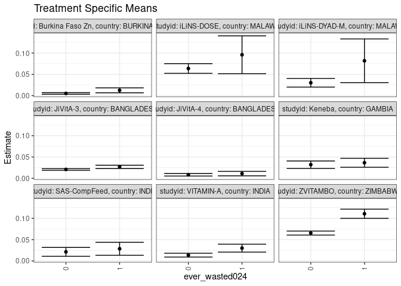

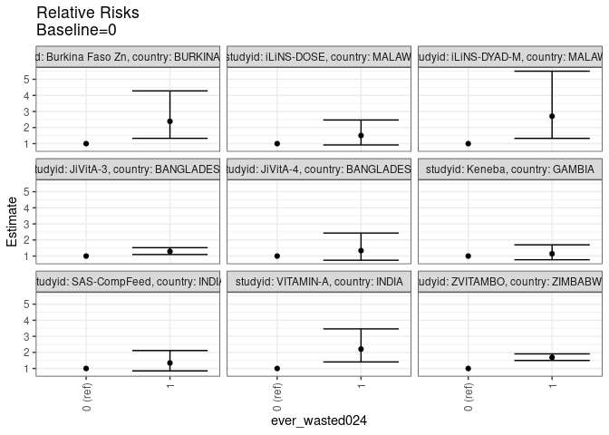

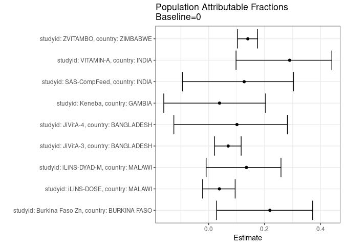

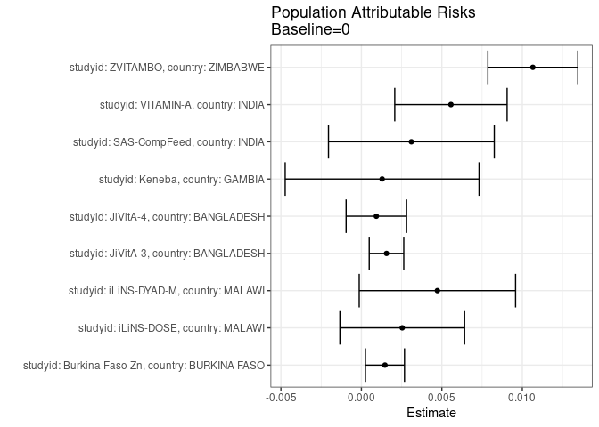

## Results Table

### Parameter: TSM

| studyid | country | intervention_level | baseline_level | estimate | ci_lower | ci_upper |
| --- | --- | --- | --- | --- | --- | --- |
| Burkina Faso Zn | BURKINA FASO | 0 | NA | 0.0052324 | 0.0033659 | 0.0070990 |
| Burkina Faso Zn | BURKINA FASO | 1 | NA | 0.0124877 | 0.0067123 | 0.0182630 |
| iLiNS-DOSE | MALAWI | 0 | NA | 0.0637479 | 0.0523759 | 0.0751200 |
| iLiNS-DOSE | MALAWI | 1 | NA | 0.0959478 | 0.0516034 | 0.1402922 |
| iLiNS-DYAD-M | MALAWI | 0 | NA | 0.0302475 | 0.0200805 | 0.0404145 |
| iLiNS-DYAD-M | MALAWI | 1 | NA | 0.0818182 | 0.0305767 | 0.1330597 |
| JiVitA-3 | BANGLADESH | 0 | NA | 0.0208090 | 0.0188440 | 0.0227740 |
| JiVitA-3 | BANGLADESH | 1 | NA | 0.0268704 | 0.0230895 | 0.0306514 |
| JiVitA-4 | BANGLADESH | 0 | NA | 0.0082565 | 0.0053412 | 0.0111719 |
| JiVitA-4 | BANGLADESH | 1 | NA | 0.0110612 | 0.0057753 | 0.0163471 |
| Keneba | GAMBIA | 0 | NA | 0.0319304 | 0.0232325 | 0.0406283 |
| Keneba | GAMBIA | 1 | NA | 0.0365210 | 0.0260210 | 0.0470211 |
| SAS-CompFeed | INDIA | 0 | NA | 0.0213481 | 0.0109504 | 0.0317458 |
| SAS-CompFeed | INDIA | 1 | NA | 0.0286293 | 0.0133724 | 0.0438861 |
| VITAMIN-A | INDIA | 0 | NA | 0.0136465 | 0.0091718 | 0.0181212 |
| VITAMIN-A | INDIA | 1 | NA | 0.0301138 | 0.0208034 | 0.0394241 |
| ZVITAMBO | ZIMBABWE | 0 | NA | 0.0654954 | 0.0608022 | 0.0701887 |
| ZVITAMBO | ZIMBABWE | 1 | NA | 0.1107786 | 0.0999706 | 0.1215865 |

### Parameter: E(Y)

| studyid | country | intervention_level | baseline_level | estimate | ci_lower | ci_upper |
| --- | --- | --- | --- | --- | --- | --- |
| Burkina Faso Zn | BURKINA FASO | NA | NA | 0.0066983 | 0.0048096 | 0.0085870 |
| iLiNS-DOSE | MALAWI | NA | NA | 0.0662869 | 0.0551877 | 0.0773861 |
| iLiNS-DYAD-M | MALAWI | NA | NA | 0.0349709 | 0.0245769 | 0.0453648 |
| JiVitA-3 | BANGLADESH | NA | NA | 0.0223698 | 0.0205726 | 0.0241670 |
| JiVitA-4 | BANGLADESH | NA | NA | 0.0091861 | 0.0065991 | 0.0117731 |
| Keneba | GAMBIA | NA | NA | 0.0332192 | 0.0267180 | 0.0397203 |
| SAS-CompFeed | INDIA | NA | NA | 0.0244547 | 0.0133604 | 0.0355490 |
| VITAMIN-A | INDIA | NA | NA | 0.0192111 | 0.0149047 | 0.0235174 |
| ZVITAMBO | ZIMBABWE | NA | NA | 0.0761509 | 0.0717486 | 0.0805531 |

### Parameter: RR

| studyid | country | intervention_level | baseline_level | estimate | ci_lower | ci_upper |
| --- | --- | --- | --- | --- | --- | --- |
| Burkina Faso Zn | BURKINA FASO | 0 | 0 | 1.000000 | 1.0000000 | 1.000000 |
| Burkina Faso Zn | BURKINA FASO | 1 | 0 | 2.386583 | 1.3309081 | 4.279620 |
| iLiNS-DOSE | MALAWI | 0 | 0 | 1.000000 | 1.0000000 | 1.000000 |
| iLiNS-DOSE | MALAWI | 1 | 0 | 1.505113 | 0.9169084 | 2.470655 |
| iLiNS-DYAD-M | MALAWI | 0 | 0 | 1.000000 | 1.0000000 | 1.000000 |
| iLiNS-DYAD-M | MALAWI | 1 | 0 | 2.704959 | 1.3288351 | 5.506177 |
| JiVitA-3 | BANGLADESH | 0 | 0 | 1.000000 | 1.0000000 | 1.000000 |
| JiVitA-3 | BANGLADESH | 1 | 0 | 1.291288 | 1.0953378 | 1.522293 |
| JiVitA-4 | BANGLADESH | 0 | 0 | 1.000000 | 1.0000000 | 1.000000 |
| JiVitA-4 | BANGLADESH | 1 | 0 | 1.339699 | 0.7386367 | 2.429875 |
| Keneba | GAMBIA | 0 | 0 | 1.000000 | 1.0000000 | 1.000000 |
| Keneba | GAMBIA | 1 | 0 | 1.143771 | 0.7695603 | 1.699949 |
| SAS-CompFeed | INDIA | 0 | 0 | 1.000000 | 1.0000000 | 1.000000 |
| SAS-CompFeed | INDIA | 1 | 0 | 1.341069 | 0.8497612 | 2.116436 |
| VITAMIN-A | INDIA | 0 | 0 | 1.000000 | 1.0000000 | 1.000000 |
| VITAMIN-A | INDIA | 1 | 0 | 2.206706 | 1.4060972 | 3.463169 |
| ZVITAMBO | ZIMBABWE | 0 | 0 | 1.000000 | 1.0000000 | 1.000000 |
| ZVITAMBO | ZIMBABWE | 1 | 0 | 1.691394 | 1.4996955 | 1.907596 |

### Parameter: PAR

| studyid | country | intervention_level | baseline_level | estimate | ci_lower | ci_upper |
| --- | --- | --- | --- | --- | --- | --- |
| Burkina Faso Zn | BURKINA FASO | 0 | NA | 0.0014659 | 0.0002522 | 0.0026795 |
| iLiNS-DOSE | MALAWI | 0 | NA | 0.0025390 | -0.0013360 | 0.0064139 |
| iLiNS-DYAD-M | MALAWI | 0 | NA | 0.0047234 | -0.0001348 | 0.0095816 |
| JiVitA-3 | BANGLADESH | 0 | NA | 0.0015608 | 0.0004877 | 0.0026339 |
| JiVitA-4 | BANGLADESH | 0 | NA | 0.0009296 | -0.0009492 | 0.0028084 |
| Keneba | GAMBIA | 0 | NA | 0.0012888 | -0.0047344 | 0.0073121 |
| SAS-CompFeed | INDIA | 0 | NA | 0.0031066 | -0.0020442 | 0.0082575 |
| VITAMIN-A | INDIA | 0 | NA | 0.0055646 | 0.0020742 | 0.0090550 |
| ZVITAMBO | ZIMBABWE | 0 | NA | 0.0106554 | 0.0078599 | 0.0134510 |

### Parameter: PAF

| studyid | country | intervention_level | baseline_level | estimate | ci_lower | ci_upper |
| --- | --- | --- | --- | --- | --- | --- |
| Burkina Faso Zn | BURKINA FASO | 0 | NA | 0.2188402 | 0.0283895 | 0.3719595 |
| iLiNS-DOSE | MALAWI | 0 | NA | 0.0383026 | -0.0216377 | 0.0947262 |
| iLiNS-DYAD-M | MALAWI | 0 | NA | 0.1350661 | -0.0091398 | 0.2586651 |
| JiVitA-3 | BANGLADESH | 0 | NA | 0.0697718 | 0.0209947 | 0.1161187 |
| JiVitA-4 | BANGLADESH | 0 | NA | 0.1011972 | -0.1246010 | 0.2816595 |
| Keneba | GAMBIA | 0 | NA | 0.0387970 | -0.1606047 | 0.2039399 |
| SAS-CompFeed | INDIA | 0 | NA | 0.1270358 | -0.0941567 | 0.3035124 |
| VITAMIN-A | INDIA | 0 | NA | 0.2896555 | 0.0978691 | 0.4406696 |
| ZVITAMBO | ZIMBABWE | 0 | NA | 0.1399254 | 0.1032716 | 0.1750809 |